# rBLAST

Prof. Harbert

# BLAST: Basic Local Alignment Search Tool

BLAST (Basic Local Alignment Search Tool) optimizes time complexity in pairwise alignment by searching for short, local, sequence matches and then extending the comparison out from the matching regions.

Some good resources to review later:

- http://www.metagenomics.wiki/tools/blast
- https://www.ndsu.edu/pubweb/~mcclean/plsc411/Blast-explanation-lecture-and-overhead.pdf

## Web BLAST

Most people first interact with BLAST via the [web portal](https://blast.ncbi.nlm.nih.gov/Blast.cgi?PROGRAM=blastn&PAGE_TYPE=BlastSearch&LINK_LOC=blasthome).

In the web portal search for this sequence:

“CATTTCAGGTGTGGGTGTTTATGATTGCGCCCTACCGTGACGTTTTCATCTATCGGAGGG…”

What is it? ^^^

How can we tell?

How are E values like p-values?

*We will revisit command line BLAST tools in our later metagenomics unit*

# rBlast

[The rBLAST package](https://github.com/mhahsler/rBLAST/) provides R code tools that implement access to the commandline BLAST tools in R. Today we will use this package to build a new BLAST database, run BLAST queries, and visualize the results in ggplot.

## Getting Started

```r
#install.packages('devtools')
#devtools::install_github("mhahsler/rBLAST")
library(rBLAST)
library(ggplot2)
```

## Get data

Download FASTQ sequence read data from the NCBI SRA:

```bash
fastq-dump SRR13764788
```

## Read into R

```r
fq <- readDNAStringSet('SRR13764788.fastq',format = 'fastq')
head(fq)
```

```
## DNAStringSet object of length 6:
##     width seq                                               names
## [1]   501 CCATGAATTAGAAAGGCGGCCTA...AACGTTAAGGGTCTTTCTAAAGA SRR13764788.1 1 l...
## [2]   502 CAATGGCTGGCAGCTTCGCCCGA...GGAAATTTAGTCGGCGGGGGGAT SRR13764788.2 2 l...
## [3]   471 CATCGAGGCGGTGCTGATGTCTT...ATGACATCAGCACCGCCTCGATG SRR13764788.3 3 l...
## [4]   444 GACGTTATCCCGTGCCGAGCCTC...GAGGCTCGGCACGGGATAACGTC SRR13764788.4 4 l...
## [5]   502 CCCTTATCCTTTGTTGCCAGCGG...TTTATCACTGGCAGTCTCCTTTG SRR13764788.5 5 l...
## [6]   484 CTATTTATCAGCTCATTCATTGT...ACAATGAATGAGCTGATAAATAG SRR13764788.6 6 l...
```

*Think: What tools can we use to look at these FASTQ sequence reads?*

## Database: Reference Genome

```r
download.file('ftp://ftp.ncbi.nlm.nih.gov/genomes/refseq/bacteria/Escherichia_coli/reference/GCF_000005845.2_ASM584v2/GCF_000005845.2_ASM584v2_genomic.fna.gz',
              'genome.fna.gz')
system('gunzip genome.fna.gz')
genome = readDNAStringSet('genome.fna')
print(genome)
```

```
## DNAStringSet object of length 1:
##       width seq                                             names
## [1] 4641652 AGCTTTTCATTCTGACTGCAAC...AACGCCTTAGTAAGTATTTTTC NC_000913.3 Esche...
```

*Think: What tools do we have to explore this genome?*

## Setting up BLAST in R

Set variables to reference (genome) and reads (SRA reads file).

```r
reference = 'genome.fna'
reads = 'SRR13764788.fastq'
dna <- readDNAStringSet(reads, format='fastq')
geno.freq = as.data.frame(alphabetFrequency(dna))
dna <- dna[geno.freq$N==0]
```

Make BLAST database from reference.

```r
#makeblastdb creates a folder that contains a blast database
makeblastdb(reference, dbtype = "nucl")
```

Prepare a BLAST query

```r
#prepare
bl <- blast(db=reference, type='blastn')
#run
cl <- predict(bl, dna, BLAST_args="-max_target_seqs 1")

cl[1:5,]
```

|  | QueryID | SubjectID | Perc.Ident | Alignment.Length | Mismatches | Gap.Openings | Q.start | Q.end | S.start | S.end | E | Bits |
| --- | --- | --- | --- | --- | --- | --- | --- | --- | --- | --- | --- | --- |
| 1 | SRR13764788.3 | NC_000913.3 | 99.550 | 222 | 1 | 0 | 250 | 471 | 2454143 | 2453922 | 1.74e-113 | 405 |
| 2 | SRR13764788.3 | NC_000913.3 | 97.285 | 221 | 6 | 0 | 1 | 221 | 2453922 | 2454142 | 1.36e-104 | 375 |
| 3 | SRR13764788.5 | NC_000913.3 | 99.606 | 254 | 1 | 0 | 1 | 254 | 2730046 | 2729793 | 3.02e-131 | 464 |
| 4 | SRR13764788.5 | NC_000913.3 | 99.606 | 254 | 1 | 0 | 1 | 254 | 3427651 | 3427398 | 3.02e-131 | 464 |
| 5 | SRR13764788.5 | NC_000913.3 | 100.000 | 251 | 0 | 0 | 1 | 251 | 3942919 | 3943169 | 3.02e-131 | 464 |

```r
#to view first 5 hits
```

## Visualize BLAST hits

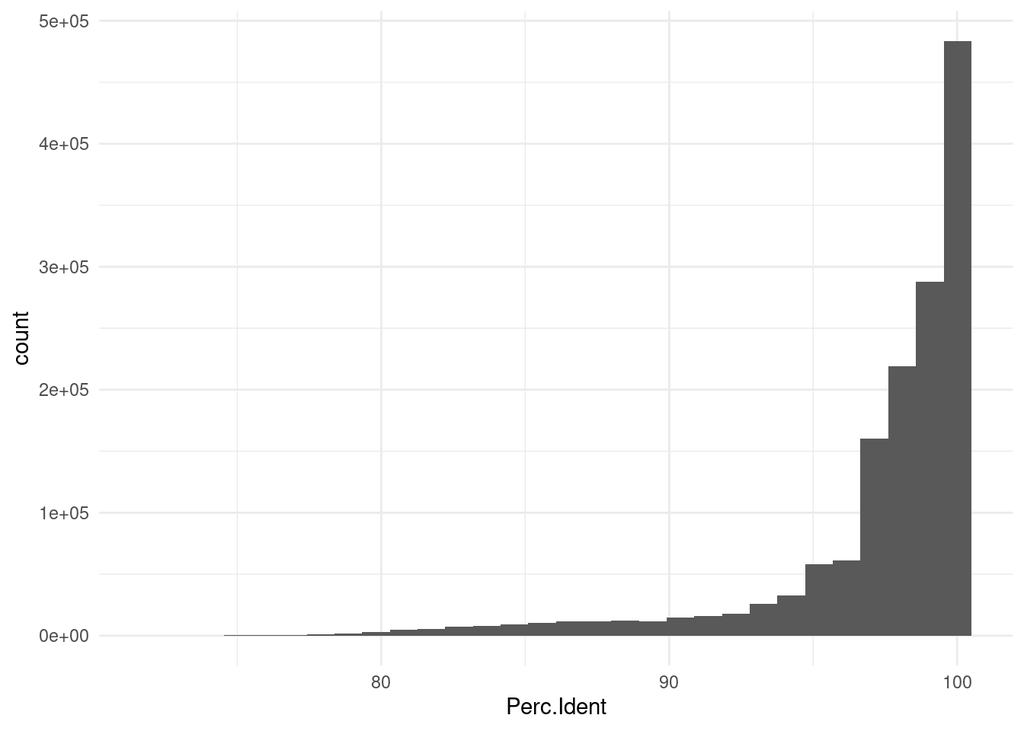

```r
ggplot(cl) +
  geom_histogram(aes(x=Perc.Ident)) +
  theme_minimal()
```

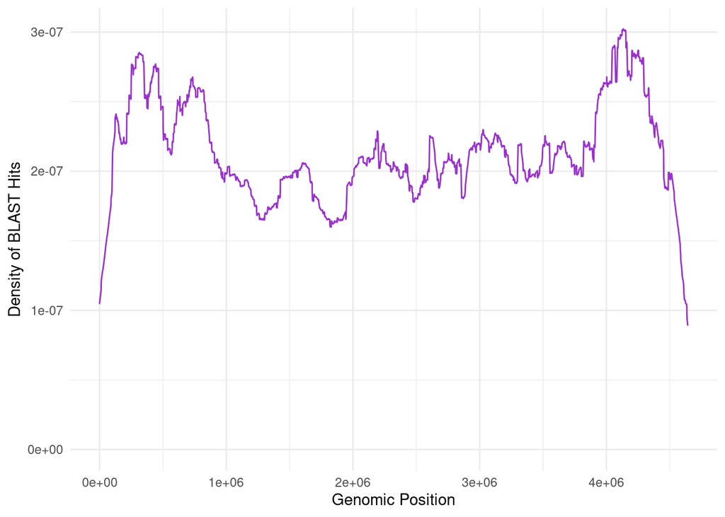

```r
ggplot(cl) +
  geom_density(aes(x=S.start),
               kernel = 'rectangular',
               n=4600,
               col='darkorchid') +
  theme_minimal() +
  xlab("Genomic Position") +
  ylab("Density of BLAST Hits")
```

[home](https://bio331.devbioinformatics.org)